# GEOB 308 FRASER LOWLAND FIELD TRIP

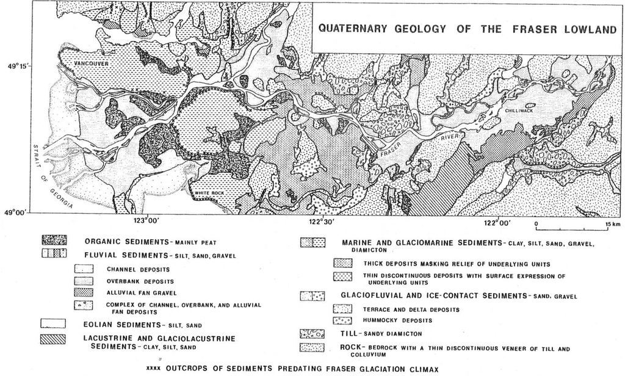

Figure 1. Generalized surficial geology of the Fraser Lowland. Adapted, in part, from Armstrong, (1980a, b) and Armstrong and Hicock (1980a, b).

## Introduction

Interpreting landforms and surficial materials in the field is an integral part of the geomorphologist’s art. To help you further understand the Quaternary history of the region, and to apply some of the theory we have explored in lecture and in the labs, this virtual field trip will introduce you to Quaternary sedimentary deposits and landforms across the Fraser Lowland.

Throughout the Quaternary, British Columbia has been repeatedly covered by extensive lobes of ice that have periodically coalesced to form a large continental ice sheet, the Cordilleran Ice Sheet. As a result, the surficial materials and landforms throughout much of the province reflect erosion and deposition from repeated Pleistocene glaciation, and generally bear no relationship to the underlying lithology (Clague and Luternauer, 1983). The Fraser Lowland experienced both repeated glaciations and deglaciations during the late Quaternary period, along with associated sea level transgressions and regressions. The fact that both a continental ice sheet and local sea level fluctuated in and out of this area for thousands of years, depositing a massive amount of sediment, has created a complex present-day landscape with various different Quaternary deposit types, providing the ideal substrate for a wide variety of land uses. Knowledge of glacial and de-glacial processes is therefore central to understanding the nature and distribution of surficial materials, which in turn dictate land use practices. This field investigation of the various surficial deposits and landforms around the Vancouver region will enable us to develop a reconstruction of the glacial and deglacial history of the region, and to explore how glacial processes and deposits affect current land uses

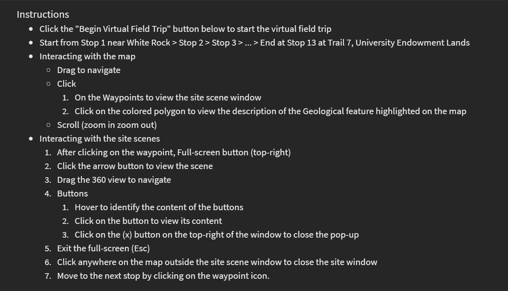

[figure not shown]